# Computing Intro

Jake Spiteri

09/12/2019

# Section 4 — Exercises

## Question 1

Computers do not represent most real numbers exactly. Rather, a real number is approximatedby the nearest real number that can be represented exactly (floating point number), given somescheme for representing real numbers as fixed length binary sequences. Often the approximation is not noticeable, but it can make a big difference relative to exact arithmetic (imagine thatyou want to know the difference between 2 distinct real numbers that are approximated by thesamebinary sequence, for example).

One consequence of working infinite precision arithmeticis that for any numberx, there is a small number $\epsilon$ for which $x+\epsilon$is indistinguishable from $x$ (with any number smaller than this having the same property).

### Part (a)

```r
eps <- 1
x <- 1
while(x+eps != x)
  eps <- eps/2
eps/x
```

```
## [1] 1.110223e-16
```

### Part (b)

```r
eps <- 1e-18; x <- 1
while(x == x+eps)
  eps <- eps+1e-18
eps
```

```
## [1] 1.12e-16
```

### Part (c)

```r
2*eps
```

```
## [1] 2.24e-16
```

```r
.Machine$double.eps
```

```
## [1] 2.220446e-16
```

### Part (d)

```r
eps <- 1; x <- 1/4
while(x+eps != x)
  eps <- eps/2
eps/x
```

```
## [1] 1.110223e-16
```

## Question 2

### Part (a)

R is an interpreted language. Instructions are interpreted ‘on the fly’. This tends to meanthat it is efficient to code in such a way that many calculations are performed per interpretedinstruction. Often this implies that loops should be avoided, otherwise R can spend much moretime interpreting the instructions to carry out a calculation than on performing the calculation itself.

```r
# rewrite this
system.time({
X <- matrix(runif(100000),1000,100)
z <- rep(0,1000)
for(i in 1:1000){
  for(j in 1:100) z[i] <- z[i] + X[i,j]
}
})
```

```
##    user  system elapsed
##   0.020   0.001   0.026
```

```r
# using apply
system.time({
z <- apply(X, 1, sum)
})
```

```
##    user  system elapsed
##   0.003   0.001   0.003
```

```r
# using rowSums
system.time({
z <- rowSums(X)
})
```

```
##    user  system elapsed
##   0.001   0.001   0.001
```

```r
# using vectorization
system.time({
ones <- rep(1,100)
z <- X %*% ones
})
```

```
##    user  system elapsed
##   0.001   0.000   0.001
```

### Part (b)

```r
# rewrite the following
system.time({
n <- 100000
z <- rnorm(n)
zneg <- 0; j <- 1
for(i in 1:n){
  if(z[i]<0){
    zneg[j] <- z[i]
    j <- j + 1
  }
}
})
```

```
##    user  system elapsed
##   0.036   0.006   0.052
```

```r
# using apply
n <- 100000
z <- rnorm(n)
system.time(
zneg <- lapply(z, function(x) x[x<0])
)
```

```
##    user  system elapsed
##   0.106   0.009   0.122
```

```r
system.time(
zneg <- z[z<0]
)
```

```
##    user  system elapsed
##   0.001   0.000   0.001
```

## Question 3

```r
set.seed(1)
n <- 1000
A <- matrix(runif(n*n),n,n)
x <- runif(n)

t(x) %*% A %*% x
```

```
##          [,1]
## [1,] 127265.6
```

```r
sum(diag(A))
```

```
## [1] 511.6692
```

```r
sum(diag((t(A) %*% diag(x) %*% A)))
```

```
## [1] 168205.1
```

## Question 4

```r
set.seed(0)
n <- 1000
A <- matrix(runif(n*n),n,n)
x.true <- runif(n)
y <- A%*%x.true
```

### Part (b)

We form the inverse of $A$ explicitly and then form $x_1 = A^{-1}y$. Note that inverting the matrix takes a long time.

```r
A.inv <- solve(A)
x.1 <- A.inv %*% y
mean(abs(x.1 - x.true))
```

```
## [1] 2.956833e-11
```

### Part (c)

We now directly solve the lienar system for $x$.

```r
x.2 <- solve(A, y)
mean(abs(x.2 - x.true))
```

```
## [1] 1.356142e-12
```

## Question 5

Write an R function which takes an un-ordered vector of observations x and returns the values of the empirical c.d.f. for each value, in the order corresponding to the original $x$ vector. (See ?sort.int.)

```r
empirical.cdf <- function(x) {
  # sort x and store length
  x.sorted <- sort(x); n <- length(x)

  # initialise cdf.hat and calculate
  cdf.hat <- rep(0,n)
  for(i in 1:n) {
    cdf.hat[i] <- sum((x.sorted < x.sorted[i]))/n
  }

  # map cdf values to original unsorted x
  cdf.hat <- cdf.hat[order(x)]

  # return cdf.hat
  return(cdf.hat)
}

empirical.cdf(runif(100))
```

```
##   [1] 0.85 0.12 0.82 0.15 0.78 0.45 0.28 0.03 0.55 0.71 0.53 0.31 0.06 0.10
##  [15] 0.77 0.97 0.09 0.72 0.87 0.88 0.80 0.86 0.61 0.23 0.74 0.79 0.27 0.25
##  [29] 0.35 0.59 0.90 0.68 0.32 0.99 0.84 0.93 0.51 0.24 0.02 0.34 0.46 0.44
##  [43] 0.98 0.48 0.66 0.41 0.57 0.13 0.54 0.22 0.92 0.16 0.07 0.67 0.63 0.65
##  [57] 0.83 0.38 0.42 0.00 0.58 0.96 0.50 0.17 0.20 0.76 0.81 0.26 0.21 0.40
##  [71] 0.62 0.95 0.60 0.11 0.75 0.69 0.47 0.14 0.52 0.70 0.64 0.33 0.04 0.43
##  [85] 0.19 0.56 0.18 0.39 0.36 0.08 0.29 0.05 0.73 0.01 0.37 0.91 0.49 0.94
##  [99] 0.30 0.89
```

### Part (b)

Modify your function to take an extra argument plot.cdf, which when TRUE will cause the empirical c.d.f. to be plotted as a step function, over a suitable $x$ range.

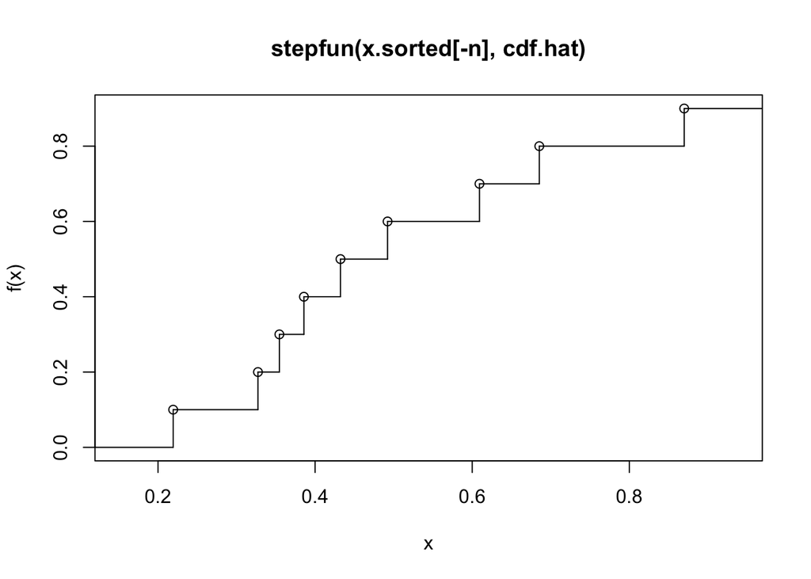

```r
empirical.cdf <- function(x, plot.cdf=TRUE) {
  # sort x and store length
  x.sorted <- sort(x); n <- length(x)

  # initialise cdf.hat and calculate
  cdf.hat <- rep(0,n)
  for(i in 1:n) {
    cdf.hat[i] <- sum((x.sorted < x.sorted[i]))/n
  }

  # cases: if plot.cdf is TRUE then plot cdf; else return cdf.hat
  if(plot.cdf) {
    # create stepfun object
    step.fn <- stepfun(x.sorted[-n], cdf.hat)
    plot(step.fn)
  } else {
      # map cdf values to original unsorted x
      cdf.hat <- cdf.hat[order(x)]
      return(cdf.hat)
  }
}

empirical.cdf(runif(10))
```

## Question 6

### Part (a)

Write an R function which takes arguments equal length vectors $x$ and $z$ and returns the vector of values of Robenbrock’s functions at each $x[i], z[i]$.

```r
rb <- function(x,z) {100*(z-x^2)^2 + (1-x)^2}
rb(seq(-10,10), seq(-10,10))
```

```
##  [1] 1210121  810100  518481  313664  176449   90036   40025   14416
##  [9]    3609     404       1       0     401    3604   14409   40016
## [17]   90025  176436  313649  518464  810081
```

### Part (b)

Produce a contour plot over the rectangle $-1.5 < x < 1.5$, $-0.5 < z < 1.5$.

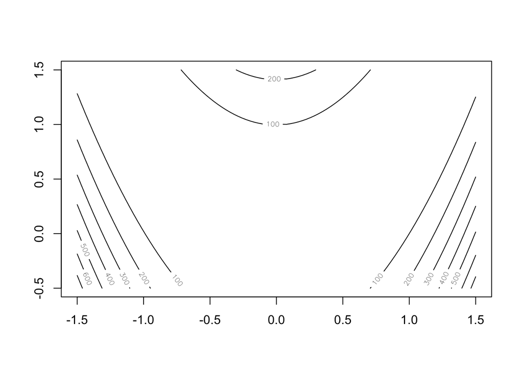

```r
# produce a matrix of evaluations of the rosenbrock function
x.seq <- seq(-1.5, 1.5, length.out=100)
z.seq <- seq(-0.5, 1.5, length.out=100)
cont.mat <- outer(x.seq,
                  z.seq,
                  Vectorize(function(x,z) rb(x,z)))
contour(x=x.seq, y=z.seq, cont.mat)
```

### Part (c)

We form the contour of the `log10` of the function, and adjust the levels argument.

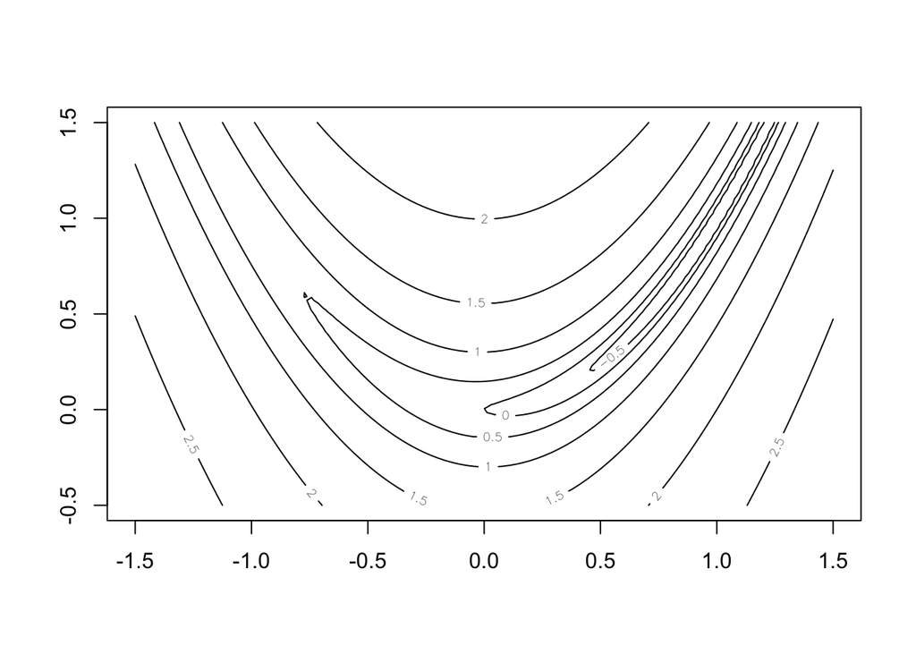

```r
cont.mat <- outer(x.seq,
                  z.seq,
                  Vectorize(function(x,z) log10(rb(x,z))))
contour(x.seq, z.seq, cont.mat, levels = seq(-0.5,2.5, 0.5))
```